# Final Project Markdown

Oropendola

2024-11-07

## 1: Data wrangling and explanation

Research Question: Does a higher density of non-renewable energy power plants correlate with worse air quality index (AQI) levels in U.S. counties?

The data comes from two main sources: the Environmental Protection Agency’s Pre-Generated Data Files, which provide daily AQI levels for each county, and the U.S. Energy Atlas and Energy Information Administration, which detail power plant locations and energy sources.The predictor variable is the density of non-renewable energy power plants, measured as the number of such plants per county. The response variable is the average daily AQI levels for each county. The general prediction is that counties with a higher density of non-renewable energy power plants will, on average, experience worse air quality compared to counties with fewer non-renewable plants. To get an understanding of what “worse air quality” entails, the EPA provides a scale that groups the numbers into how much of a health concern it is, corresponded with a color. You can typically see this scale in easy to obtain places such as the weather app, online, or on the news.

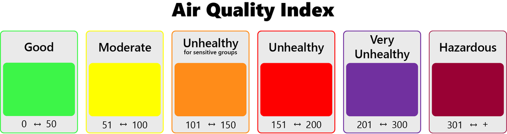

EPA AQI Table from the CDC Website

I started the data wrangling process started by standardizing state and county columns by case for easy merging. Focusing on the contiguous U.S., I filtered out Alaska, Hawaii, and Puerto Rico to keep things simple and improve map visuals. Missing (NA) values in the data were also replaced with zeros.

Power plants were grouped into renewable and non-renewable categories, with coal, petroleum, natural gas, and nuclear classified as non-renewable. Then, I created a column for the count of the non-renewable plants in each county and state. For AQI data, I calculated the average daily AQI for each county and identified the most common AQI category (“Good” or “Moderate”).

Next, I combined the datasets by matching counties and states, ensuring areas without non-renewable plants were included with a count of zero. For mapping, this data was merged with state and county boundaries and the filtered non-renewable plant locations to prepare for visualizations.

```r
require(leaflet)
require(tidyverse)
```

```r
require(lubridate)
require(maps)
require(mapproj)
require(gridExtra)
require(sf)
require(dplyr)
require(AICcmodavg)
power_plants <- read.csv("Power_Plants.csv",
                         stringsAsFactors = F)
aqi_data <- read.csv("daily_aqi_by_county_2024.csv",
                     stringsAsFactors = F)
# Load US state boundaries
states <- map_data("state")
counties <- map_data("county")
#changing case
states$region <- str_to_title(states$region)
counties$region <- str_to_title(counties$region)
counties$subregion <- str_to_title(counties$subregion)
states$region <- as.factor(states$region)
counties$region <- as.factor(counties$region)
counties$subregion <- as.factor(counties$subregion)

#Filter out Alaska & Hawaii
states <-states %>%
  filter(region != "Alaska",
         region != "Hawaii",
         region != "Puerto Rico") %>%
  droplevels()

power_plants <-power_plants %>%
  filter(State != "Alaska",
         State != "Hawaii",
         State != "Puerto Rico") %>%
  droplevels()

aqi_data <-aqi_data %>%
  filter(State.Name != "Alaska",
         State.Name != "Hawaii",
         State.Name != "Puerto Rico") %>%
  droplevels()


#Changing all N/A entries to 0; a coal plant doesn't output hydro-electric MW
power_plants[is.na(power_plants)] <- 0
aqi_data[is.na(aqi_data)] <- 0

#Grouping Non-Renewable power plants into a new column
power_plants <- power_plants %>%
  mutate(renewable = ifelse(PrimSource %in%
                              c("coal", "petroleum", "natural gas", "nuclear"), "no", "yes"))

power_plants <- power_plants %>%
  distinct(Street_Address,County, .keep_all = TRUE)
#Filtering non-renewable power plant count by state
nonrenewable_pp <- power_plants %>%
  filter(renewable == "no") %>%
  group_by(County, State) %>%
  summarize(nonrenewable_total = length(renewable))
#Avg AQI and Mode of category name
aqi_data_avg <- aqi_data %>%
  group_by(State.Name, county.Name) %>%
  summarize(Avg_AQI = mean(AQI, na.rm = TRUE), #Average AQI for the county
            aqi_category = names(which.max(table(Category)))) #Most frequent AQI category name (mode)
#Combining non-renewable power plant data with AQI data
pp_aqi<- aqi_data_avg %>%
  left_join(nonrenewable_pp, by = c("State.Name" = "State" ,
                                 "county.Name" = "County" ))

pp_aqi[is.na(pp_aqi)] <- 0

#Combining countyboundary data and non-renewable power plants AQI information
county_pp_aqi <- counties %>%
  left_join(pp_aqi, by = c("region" = "State.Name",
                           "subregion" = "county.Name"))
#Filtering out renewable plants; including their primary source from the power_plants data set
power_plants_nonrenewable <- power_plants %>%
  filter(renewable == "no") %>%
  select(State, County, PrimSource, Longitude, Latitude)


nonrenewable_type <- power_plants %>%
  filter(renewable == "no") %>%
  select(Longitude, Latitude, PrimSource, State, County)
```

## 2: Space or Time or Space/Time Visualizations

The first map highlights the distribution of non-renewable energy power plants by county. Counties with higher densities appear to be more concentrated in industrial regions and near population centers, which correlates with energy demands and economic activity.

The second map highlights the distribution of average AQI levels. Counties with higher AQI values (indicating worse air quality) often correspond with areas of high non-renewable power plant density.

The third map was supplemental, showing each non-renewable power plant as of 2024 in the contiguous united states. This gave insight into the most used non-renewable power sources such as natural gas and petroleum.

Regions with a high density of non-renewable power plants often coincide with counties experiencing higher AQI levels. However, additional factors, such as industrial emissions, vehicle traffic, and geography, may also influence these patterns.

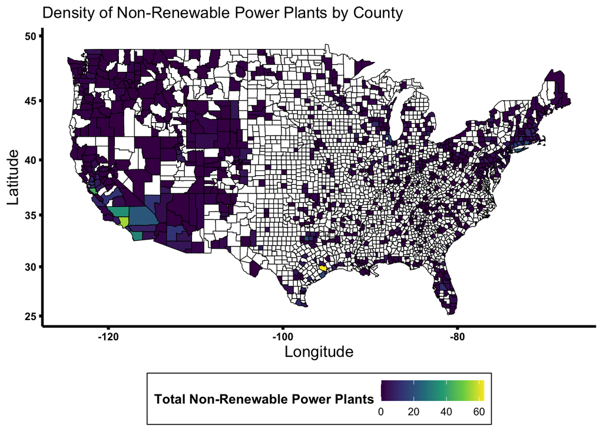

```r
#Gradient density map
ggplot(data = county_pp_aqi,
       aes(x = long,
           y = lat,
           group = group,
           fill = nonrenewable_total))+
  geom_polygon(color = "black",
               linewidth=0.25)+
  coord_map()+
  theme_classic()+
  theme(legend.position = "bottom",
    legend.margin = margin(6, 6, 6, 6),
    legend.background = element_blank(),
    legend.title = element_text(face = "bold"),
    legend.box.background = element_rect(colour = "black"),
    axis.line = element_line(colour = 'black', linewidth = 1),
    axis.text = element_text(colour = "black", face = 'bold'),
    axis.text.x = element_text(size = rel(1)),
    axis.text.y = element_text(size = rel(1)),
    axis.title = element_text(size = rel(1.2)),
    axis.ticks = element_line(colour = 'black',
                              linewidth = 1.2),)+
  scale_fill_viridis_c(na.value = "white")+
  labs(title = "Density of Non-Renewable Power Plants by County",
    x = "Longitude",
    y = "Latitude",
    fill = "Total Non-Renewable Power Plants")
```

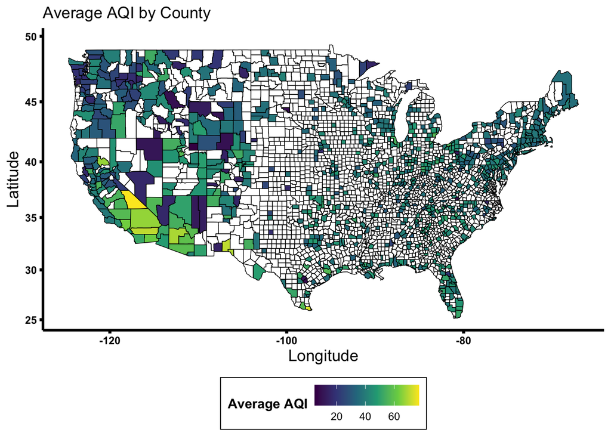

```r
ggplot(data = county_pp_aqi,
       aes(x = long,
           y = lat,
           group = group,
           fill = Avg_AQI))+
  geom_polygon(color = "black",
               linewidth=0.25)+
  coord_map()+
  theme_classic()+
  theme(legend.position = "bottom",
    legend.margin = margin(6, 6, 6, 6),
    legend.background = element_blank(),
    legend.title = element_text(face = "bold"),
    legend.box.background = element_rect(colour = "black"),
    axis.line = element_line(colour = 'black', linewidth = 1),
    axis.text = element_text(colour = "black", face = 'bold'),
    axis.text.x = element_text(size = rel(1)),
    axis.text.y = element_text(size = rel(1)),
    axis.title = element_text(size = rel(1.2)),
    axis.ticks = element_line(colour = 'black',
                              linewidth = 1.2),)+
  scale_fill_viridis_c(na.value = "white")+
  labs(title = "Average AQI by County",
    x = "Longitude",
    y = "Latitude",
    fill = "Average AQI")
```

```r
#Fun embedded map to show the non-renewable power plants by source type
leaflet(data = power_plants_nonrenewable) %>%
  addTiles() %>%
  addProviderTiles("OpenStreetMap.Mapnik")%>%
  addCircleMarkers(~Longitude, ~Latitude,
    color = ~ifelse(PrimSource == "coal", "black",
             ifelse(PrimSource == "nuclear", "orange",
             ifelse(PrimSource == "natural gas", "blue",
             ifelse(PrimSource == "petroleum", "red", "gray")))),
    radius = 2,
    popup = ~paste("PrimSource:", PrimSource)) %>%
  addLegend("bottomright",
    colors = c("black", "orange", "blue", "red", "gray"),
    labels = c("Coal", "Nuclear", "Natural Gas", "Petroleum", "Other"),
    title = "Primary Source Type",
    opacity = 1)
```

[interactive chart not shown]

## 3: Diagnostic plots and data scaling

[figure not shown]

```r
#AQI distribution
h1 <- ggplot(aqi_data_avg,
       aes(x = Avg_AQI))+
  geom_histogram(bins = 10,
                 fill = "blue",
                 color = "black",
                 alpha = 0.7) +
  labs(title = "Normal-ish Distribution",
       x = "Average AQI",
       y = "Frequency")+
  theme_classic()+
  theme(plot.title = element_text(size = rel(1.5),
                                  face = 'bold'),
    axis.line = element_line(colour = 'black',
                                 linewidth = 1),
    axis.text = element_text(colour = "black",
                             face = 'bold'),
    axis.text.x = element_text(size = rel(1)),
    axis.text.y = element_text(size = rel(1)),
    axis.title = element_text(size = rel(1.1)),
    axis.ticks = element_line(colour = 'black',
                              linewidth = 1.2),)

#Power plant density distribution
h2 <-
  ggplot(nonrenewable_pp,
       aes(x = nonrenewable_total))+
  geom_histogram(bins = 10,
                 fill = "red",
                 color = "black",
                 alpha = 0.7)+
  labs(title = "Left Skewed Distribution",
       x = "Non-Renewable Power Plant \nDensity per County",
       y = "Frequency")+
  theme_classic()+
  theme(plot.title = element_text(size = rel(1.5),
                                  face = 'bold'),
    axis.line = element_line(colour = 'black',
                                 linewidth = 1),
    axis.text = element_text(colour = "black",
                             face = 'bold'),
    axis.text.x = element_text(size = rel(1)),
    axis.text.y = element_text(size = rel(1)),
    axis.title = element_text(size = rel(1.1)),
    axis.ticks = element_line(colour = 'black',
                              linewidth = 1.2),)

county_pp_aqi <- county_pp_aqi %>%
 left_join(power_plants_nonrenewable, by = c("region" = "State",
                                   "subregion" = "County"))
scttr <-
  ggplot(data = county_pp_aqi,
       aes(x = nonrenewable_total,
           y = Avg_AQI))+
  geom_point(alpha = 0.07,
             size = 3,
             shape = 19,
             color = "forestgreen")+
  geom_point(shape = 1,size = 3,color = "black")+
  geom_smooth(method = "lm",
              color = "red",
              linetype = "solid")+
  labs(title = "Linear Relationship",
    x = "Density of Non-Renewable \nPower Plants per County",
    y = "Average AQI")+
  theme_classic()+
  theme(plot.title = element_text(size = rel(1.5),
                                  face = 'bold'),
    axis.line = element_line(colour = 'black',
                                 linewidth = 1),
    axis.text = element_text(colour = "black",
                             face = 'bold'),
    axis.text.x = element_text(size = rel(1)),
    axis.text.y = element_text(size = rel(1)),
    axis.title = element_text(size = rel(1.1)),
    axis.ticks = element_line(colour = 'black',
                              linewidth = 1.2),)


#Putting all diagnostic plots in one figure

grid.arrange(h1, h2, scttr, nrow = 2)
```

```r
#Conducting a Cor test to understand the strength of the correlation between the two variables
cor.test <-
  cor.test(pp_aqi$nonrenewable_total,
         pp_aqi$Avg_AQI)
cor.test
```

```
##
##  Pearson's product-moment correlation
##
## data:  pp_aqi$nonrenewable_total and pp_aqi$Avg_AQI
## t = 7.4594, df = 925, p-value = 2.001e-13
## alternative hypothesis: true correlation is not equal to 0
## 95 percent confidence interval:
##  0.1765209 0.2980203
## sample estimates:
##       cor
## 0.2382024
```

## 4: Analysis & visualization

```r
linearregret <- pp_aqi %>% lm(formula = Avg_AQI ~ nonrenewable_total)
summary(linearregret)
```

```
##
## Call:
## lm(formula = Avg_AQI ~ nonrenewable_total, data = .)
##
## Residuals:
##     Min      1Q  Median      3Q     Max
## -33.327  -3.798   0.772   5.469  39.323
##
## Coefficients:
##                    Estimate Std. Error t value Pr(>|t|)
## (Intercept)        37.95302    0.32657 116.216   <2e-16 ***
## nonrenewable_total  0.50241    0.06735   7.459    2e-13 ***
## ---
## Signif. codes:  0 '***' 0.001 '**' 0.01 '*' 0.05 '.' 0.1 ' ' 1
##
## Residual standard error: 9.078 on 925 degrees of freedom
## Multiple R-squared:  0.05674,    Adjusted R-squared:  0.05572
## F-statistic: 55.64 on 1 and 925 DF,  p-value: 2.001e-13
```

```r
polyregret <- pp_aqi %>% lm(formula = Avg_AQI ~ nonrenewable_total+ I(nonrenewable_total^2))
summary((polyregret))
```

```
##
## Call:
## lm(formula = Avg_AQI ~ nonrenewable_total + I(nonrenewable_total^2),
##     data = .)
##
## Residuals:
##     Min      1Q  Median      3Q     Max
## -32.885  -3.991   0.767   5.522  39.765
##
## Coefficients:
##                          Estimate Std. Error t value Pr(>|t|)
## (Intercept)             37.511726   0.356242 105.299  < 2e-16 ***
## nonrenewable_total       0.835319   0.128680   6.491 1.39e-10 ***
## I(nonrenewable_total^2) -0.009245   0.003050  -3.031   0.0025 **
## ---
## Signif. codes:  0 '***' 0.001 '**' 0.01 '*' 0.05 '.' 0.1 ' ' 1
##
## Residual standard error: 9.038 on 924 degrees of freedom
## Multiple R-squared:  0.06603,    Adjusted R-squared:  0.06401
## F-statistic: 32.66 on 2 and 924 DF,  p-value: 1.969e-14
```

```r
#Comparing models
my_modelcomparison<-aictab(cand.set = list(linearregret, polyregret),
               modnames = c("0 LinearRegret",
                            "1 PolyRegret"))
my_modelcomparison
```

```
##
## Model selection based on AICc:
##
##                K    AICc Delta_AICc AICcWt Cum.Wt       LL
## 1 PolyRegret   4 6717.18       0.00   0.97   0.97 -3354.57
## 0 LinearRegret 3 6724.33       7.16   0.03   1.00 -3359.15
```

[figure not shown]

```r
#Polynomial linear regression has the lowest AICc number!

#Creating the Polynomial Linear Regression plot; confirms there is some curvilinearity visually
ggplot(pp_aqi,
       aes(x = nonrenewable_total,
           y = Avg_AQI))+
  geom_point(alpha = 0.6,
             color = "red",
             size = 4,
             shape = 20)+
  stat_smooth(method = lm, formula = y ~ poly (x^2))+
  labs(title = "Curvilinear Regression",
       x = "Density of Non-Renewable Power Plants",
       y = "Average AQI by County")+
  theme_classic()+
  theme(plot.title = element_text(size = rel(2),
                                  face = 'bold'),
    axis.line = element_line(colour = 'black',
                             linewidth = 1),
    axis.text = element_text(colour = "black",
                             face = 'bold'),
    axis.text.x = element_text(size = rel(1)),
    axis.text.y = element_text(size = rel(1)),
    axis.title = element_text(size = rel(1.5)),
    axis.ticks = element_line(colour = 'black',
                              linewidth = 1.2),)
```

## 5: Interpretation

**H<sub>0</sub>: The number of non-renewable power plants has no effect on the average air quality index (AQI) within a county.**

**H<sub>A</sub>: The number of non-renewable power plants does affect the average air quality index (AQI) within a county.**

To determine the best-fit model for analyzing the relationship between the density of non-renewable power plants and average AQI, I compared a Linear Regression model with a Polynomial Linear Regression model. The Polynomial model was chosen based on its lower AICc value (6717.18 compared to 6724.33), indicating a better fit despite the large residuals.

While the model was significant, an adjusted R2 value of 0.064, indicates that the density of non-renewable power plants only explains 6.4% of the variation for the average AQI in each county. This would suggest that many other factors play a more significant role in a county’s average AQI.

The significant p-value (F-statistic: 32.66 on 2, DF: 924, p-value: 1.969e-14) allows me to reject the null hypothesis, suggesting that there is a relationship between non-renewable power plant density and average AQI.

In the future, I’d look into adding more variables like population density or comparing the analysis of non-renewable power plants with renewable power plants to get a fuller picture. I’d also try scaling or transforming the skewed data to improve the model and incorporating a temporal aspect to look at changes over time.

Overall, I think that that the findings of this project highlight the need for more air quality monitoring in the US. This could look like adding more monitoring stations per county or adding an air quality module to existing infrastructure.

## 6: Data Sets Citation

“AirData Website File Download Page.” Aqs.epa.gov, aqs.epa.gov/aqsweb/airdata/download_files.html#AQI.CDC.

“Power Plants.” Eia.gov, 2020, atlas.eia.gov/datasets/eia::power-plants/explore?location=37.719208%2C-80.475321%2C6.49. Accessed 14 Nov. 2024.

### Program & Packages

R Core Team (2024). *R: A Language and Environment for Statistical Computing*. R Foundation for Statistical Computing, Vienna, Austria. https://www.R-project.org/.

H. Wickham. ggplot2: Elegant Graphics for Data Analysis. Springer-Verlag New York, 2016.

Wickham H, François R, Henry L, Müller K, Vaughan D (2023). *dplyr: A Grammar of Data Manipulation*. R package version 1.1.4, https://CRAN.R-project.org/package=dplyr.

Wickham H, Averick M, Bryan J, Chang W, McGowan LD, François R, Grolemund G, Hayes A, Henry L, Hester J, Kuhn M, Pedersen TL, Miller E, Bache SM, Müller K, Ooms J, Robinson D, Seidel DP, Spinu V, Takahashi K, Vaughan D, Wilke C, Woo K, Yutani H (2019). “Welcome to the tidyverse.” *Journal of Open Source Software*, *4*(43), 1686. doi:10.21105/joss.01686 https://doi.org/10.21105/joss.01686.

Cheng J, Schloerke B, Karambelkar B, Xie Y (2024). *leaflet: Create Interactive Web Maps with the JavaScript ‘Leaflet’ Library*. R package version 2.2.2, https://CRAN.R-project.org/package=leaflet.

Garrett Grolemund, Hadley Wickham (2011). Dates and Times Made Easy with lubridate. Journal of Statistical Software, 40(3), 1-25. URL https://www.jstatsoft.org/v40/i03/.

Becker OScbRA, Minka ARWRvbRBEbTP, Deckmyn. A (2023). *maps: Draw Geographical Maps*. R package version 3.4.2, https://CRAN.R-project.org/package=maps.

Brownrigg DMPfRbR, Minka TP, Bivand. ttP9cbR (2023). *mapproj: Map Projections*. R package version 1.2.11, https://CRAN.R-project.org/package=mapproj.

Auguie B (2017). *gridExtra: Miscellaneous Functions for “Grid” Graphics*. R package version 2.3, https://CRAN.R-project.org/package=gridExtra.

Pebesma, E., & Bivand, R. (2023). Spatial Data Science: With Applications in R. Chapman and Hall/CRC. https://doi.org/10.1201/9780429459016

Mazerolle MJ (2023). *AICcmodavg: Model selection and multimodel inference based on (Q)AIC(c)*. R package version 2.3.3, https://cran.r-project.org/package=AICcmodavg.

### Outside Code, Add-ons, and Other

CDC. “About Air Quality.” Air Quality, 14 May 2024, www.cdc.gov/air-quality/about/index.html.

“Leaflet Provider Demo.” Github.io, 2024, leaflet-extras.github.io/leaflet-providers/preview/index.html. Accessed 4 Dec. 2024.

“Top Visualisation Tricks You Should Know in R - Biostatsquid.com.” Biostatsquid.com - Easy Computational Biology and Biostatistics, Oct. 2023, biostatsquid.com/top-visualisation-tricks-r/?et_fb=1&PageSpeed=off. Accessed 3 Dec. 2024.